# Data visualization assignment

Amelia Xu

2026-09-11

In this exercise, you will practice basic plotting with **`ggplot2`** on a dataset of median gene expression levels across samples from various human tissues from the GTEx Project. The dataset (`dt`) has one row per gene, with columns:

- `Name`: the Ensembl gene ID
- `Description`: the gene symbol
- One column per tissue containing the median expression levels (in TPM units)

Insert your code into the empty code blocks. Insert answers to any comprehension questions as comments within the code blocks. You do not need to submit the figures themselves, only the code used to produce them. Remember to label your axes!

**Using HopGPT.** As in the last assignment: you are welcome to use it, and wherever you do, add a couple of comment lines in that same code block noting what you asked it and how you checked the answer.

### Load data

Start by loading the data into R, as before.

```r
library(tidyverse)

dt <- read_delim("/Users/cmdb/Data/GTEx/GTEx_Analysis_2017-06-05_v8_RNASeQCv1.1.9_gene_median_tpm.gct.gz",
                 skip = 2, col_names = TRUE, delim = "\t")
```

Recreate the `is_mitochondrial` column from the last assignment; you will need it in Q4 and Q5.

```r
dt <- dt %>%
  mutate(is_mitochondrial = str_starts(Description, "MT-"))

dt %>% count(is_mitochondrial)
```

```
## # A tibble: 2 × 2
##   is_mitochondrial     n
##   <lgl>            <int>
## 1 FALSE            56163
## 2 TRUE                37
```

### Q1. Histogram

Make a histogram of gene expression in the liver. Use the argument `breaks = seq(0, 100, 2)` to bin in units of 2 TPM, ranging from 0 to 100. Note that this cuts off the data at 100, which might be misleading depending on what we are trying to depict! How many genes are you leaving out?

What do you notice about the shape of the distribution? What does it tell you about the relative expression of genes in the liver transcriptome? Do you think this is specific to the liver? Check another tissue, as well.

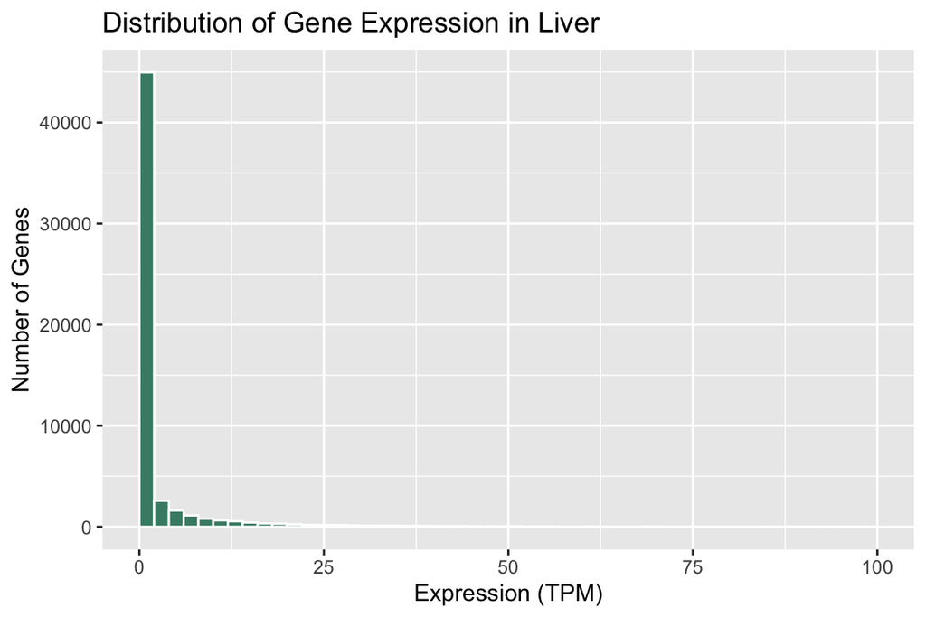

```r
# answer here
# visualization
dt %>%
  ggplot(aes(x = Liver)) +
  geom_histogram(breaks = seq(0, 100, 2),
                 fill = "aquamarine4",
                 colour = "white") +
  labs(title = "Distribution of Gene Expression in Liver",
       x = "Expression (TPM)",
       y = "Number of Genes")
```

```r
# count the number of excluded genes --- 594 genes
dt %>%
  filter(Liver > 100) %>%
  nrow()
```

```
## [1] 594
```

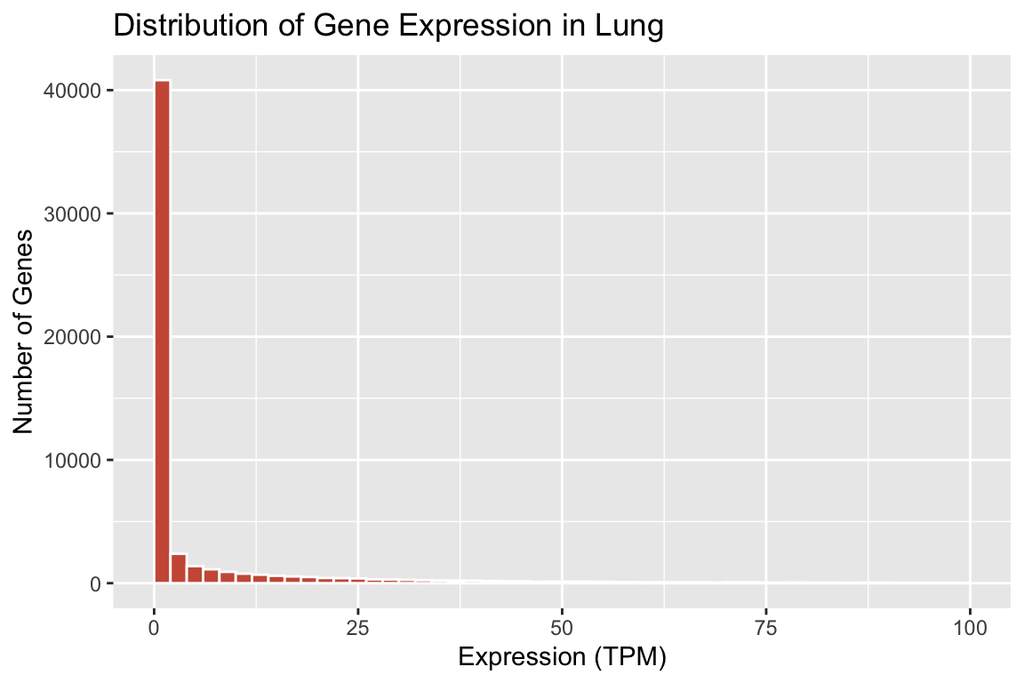

```r
# Check in lung
dt %>%
  ggplot(aes(x = Lung)) +
  geom_histogram(breaks = seq(0, 100, 2),
                 fill = "coral3",
                 colour = "white") +
  labs(title = "Distribution of Gene Expression in Lung",
       x = "Expression (TPM)",
       y = "Number of Genes")
```

```r
### The distribution is strongly right-skewed in liver. Most genes have low or zero expression in the liver, while a small number of genes are highly expressed. This pattern is not specific to the liver because the distribution in the lung is also right-skewed.
```

### Q2. Density plot

Going back to the liver, now represent the same data with a density plot rather than a histogram. Do not restrict the X axis. Within the same code block, create a second plot where you remove the custom bin breaks, but transform the expression values using `log10()`. First add a pseudo-count of 1 to the expression values, as the log of 0 is negative infinity.

What does the log-transformed version show you that the first plot does not? And where on the log-transformed plot do the genes with 0 TPM end up?

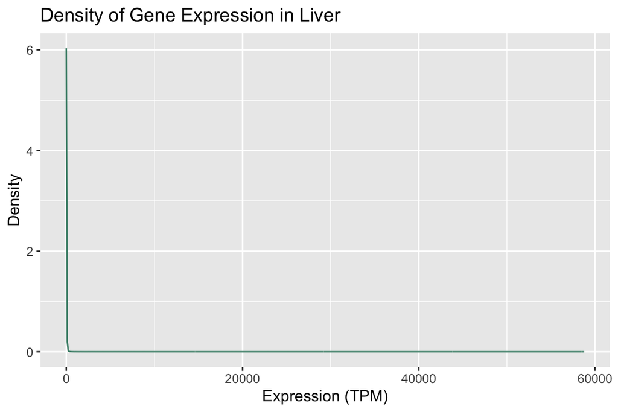

```r
# answer here
# density plot
dt %>%
  ggplot(aes(x = Liver)) +
  geom_density(colour = "aquamarine4") +
  labs(title = "Density of Gene Expression in Liver",
       x = "Expression (TPM)",
       y = "Density")
```

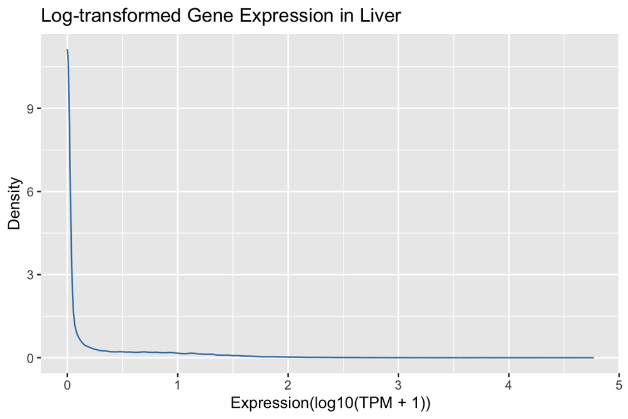

```r
# density plot
dt %>%
  ggplot(aes(x = log10(Liver+1))) +
  geom_density(colour = "steelblue") +
  labs(title = "Log-transformed Gene Expression in Liver",
       x = "Expression(log10(TPM + 1))",
       y = "Density")
```

```r
### The original plot is compressed by a small number of extremely highly expressed genes. The log-transformed plot makes the distribution of low- and moderately-expressed genes easier to see. Genes with 0 TPM appear at log10(0 + 1) = 0.
```

### Q3. Scatter plot

Make a scatter plot comparing the expression of genes in the `Liver` to the same genes in the `Heart - Left Ventricle`. Add a pseudocount to each and log10 transform them. Adjust the point size to 1 and the alpha (opacity) to 0.2. Add a dashed red line along the diagonal (y = x).

What does a point far above the diagonal mean, biologically?

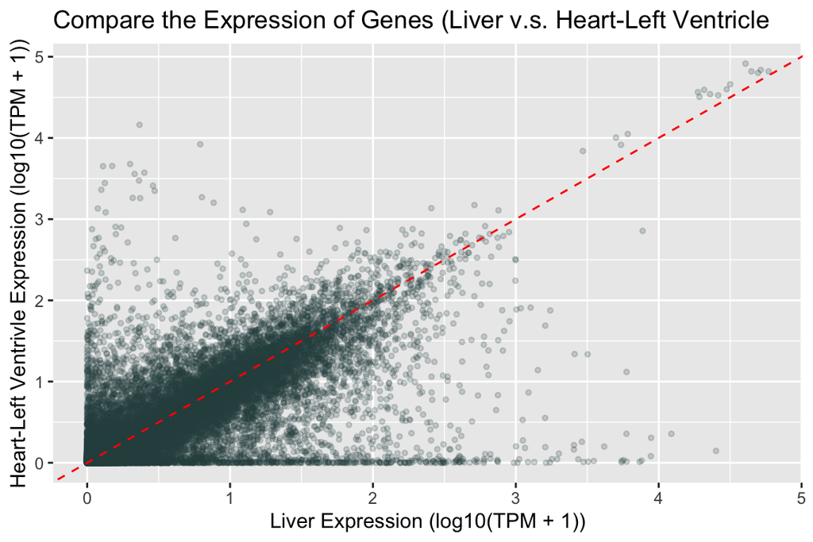

```r
# answer here
dt %>%
  ggplot(aes(x = log10(Liver + 1),
             y = log10(`Heart - Left Ventricle` + 1))) +
  geom_point(size = 1,
             alpha = 0.2,
             colour = "darkslategrey") +
  geom_abline(intercept = 0, slope = 1, linetype = "dashed", color = "red") +
  labs(title = "Compare the Expression of Genes (Liver v.s. Heart-Left Ventricle",
      x = "Liver Expression (log10(TPM + 1))",
      y = "Heart-Left Ventrivle Expression (log10(TPM + 1))")
```

```r
### A point far above the diagonal represents a gene that is expressed much more highly in the heart than in the liver.
```

### Q4. Colored points on scatter plot

Color the previous scatter plot points based on whether the genes are mitochondrial vs. nuclear encoded, using the `is_mitochondrial` column you made above.

There are only a few dozen mitochondrial genes among tens of thousands of nuclear ones, so the colored points end up buried. Try plotting them as a second `geom_point()` layer on top of the others, using the `data` argument to give that layer just the mitochondrial genes: `geom_point(data = filter(dt, is_mitochondrial), ...)`.

Where do the mitochondrial genes sit relative to the diagonal, and does that fit what you found in the last assignment?

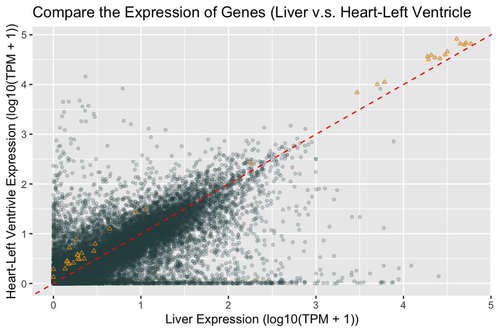

```r
# answer here
# no
dt %>%
  ggplot(aes(x = log10(Liver + 1),
             y = log10(`Heart - Left Ventricle` + 1))) +
  geom_point(size = 1,
             alpha = 0.2,
             color = "darkslategrey") +
  geom_point(data = filter(dt, is_mitochondrial),
             size = 1,
             shape = 2,
             alpha = 0.7,
             color = "orange") +
  geom_abline(intercept = 0, slope = 1, linetype = "dashed", color = "red") +
  labs(title = "Compare the Expression of Genes (Liver v.s. Heart-Left Ventricle",
       x = "Liver Expression (log10(TPM + 1))",
       y = "Heart-Left Ventrivle Expression (log10(TPM + 1))")
```

```r
### Most mitochondrial genes are above the diagonal, showing that they have higher expression in the heart than in the liver. This agrees with the previous finding because the heart requires large amounts of energy.
```